# Current Election Contributions, 2016

Kevin Palm

June 11, 2015

The data set analyzed in this project was the Federal Election Commission 2016 Presidential Campaign Finance data set corresponding to all states, available for download here: http://fec.gov/disclosurep/PDownload.do. At the time of this project’s creation, the data set only contained contribution information pertaining to one candidate, Republican Rafael Edward Ted Cruz.

Before importing to R, the data set needed to be formatted such that there were no repeat column header names. This was done by reading the .csv into a Python pandas data frame, then rewriting the .csv.

## ‘Stream-of-Consciousness’ Analysis and Exploration of the Data

### Analysis Preparations

```r
library(ggplot2)
library(gridExtra)
us = read.csv('/home/kevin/Documents/projects/Udacity/Project_3/project/US.csv')
us$contb_receipt_dt = as.Date(us$contb_receipt_dt, format = '%d-%b-%y')
us$contbr_zip = as.factor(us$contbr_zip)
```

### Basic Exploration

The project began with some basic exploration of the data set without much prior data cleaning or subsetting.

**Total Observations**

```r
nrow(us)
```

```
## [1] 2331
```

Ted Cruz had over 2000 contributions recorded in this data file.

**States Represented**

```r
unique(us$contbr_st)
```

```
##  [1] AK AL AP AR AZ CA CO CT DC DE FL GA HI IA ID IL IN KS KY LA MA MD ME
## [24] MI MN MO MS MT NC ND NE NH NJ NM NV NY OH OK OR PA RI SC TN TX UT VA
## [47] VI VT WA WI WV WY XX
## 53 Levels: AK AL AP AR AZ CA CO CT DC DE FL GA HI IA ID IL IN KS KY ... XX
```

**Contribution Amounts**

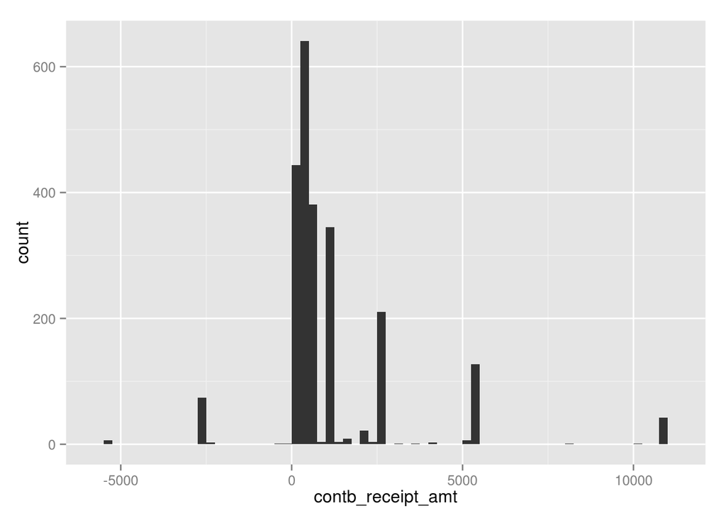

```r
qplot(data = us, x = contb_receipt_amt, binwidth = 250)
```

There were instances of negative contribution amounts within the data set. Presumably these are refunds to individuals who contributed beyond the legal limit.

**Contribution Dates**

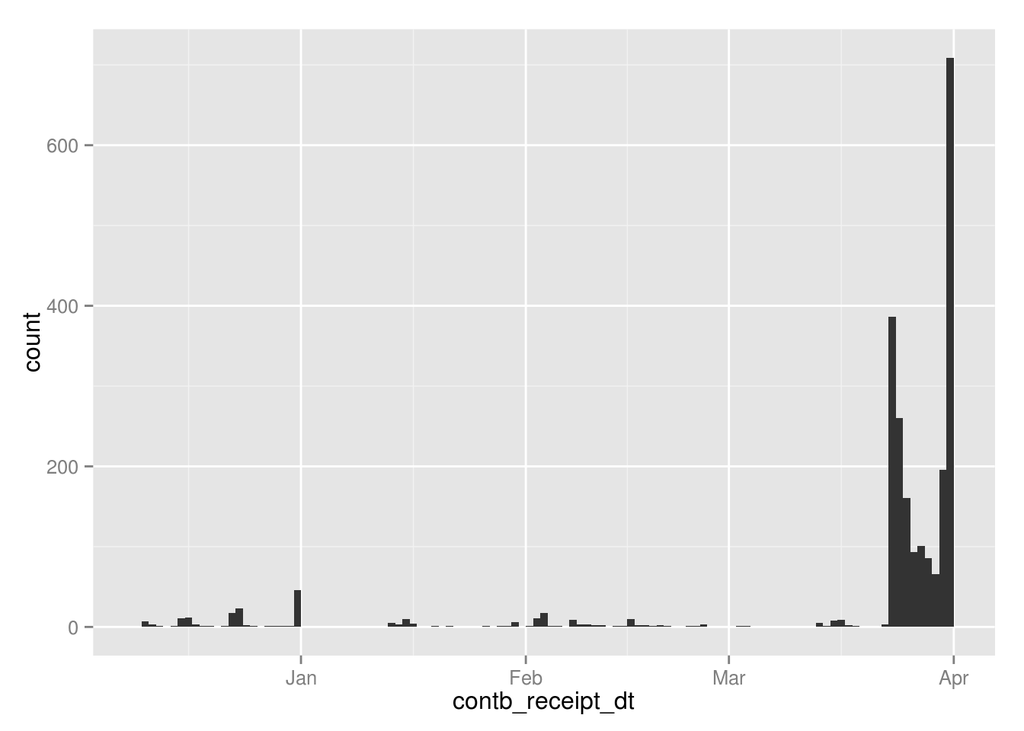

```r
qplot(data = us, x = contb_receipt_dt, binwidth = 1)
```

The date range within this data set was 2014-12-10 through 2015-03-31.

### Exploration Using Subsets and Two Variables

**Amounts vs. Dates**

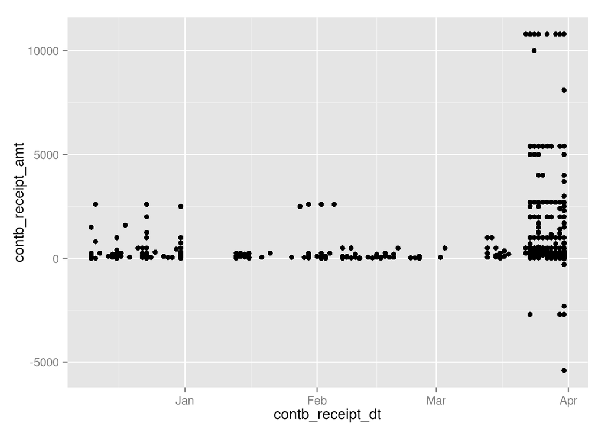

```r
qplot(data = us, x = contb_receipt_dt, y = contb_receipt_amt)
```

I replotted contribution dates, this time with price on the y-axis. The vast majority of the data points and contributed funds being located on or after March 23rd makes sense, as this was the day that the Texas senator officially announced his presidential run. At first I thought the distribution looked strangely patterned, perhaps even suspicious. Later I realized that some of the more ‘regular’ numbers which contributors choose to contribute were just occurring daily.

**Amounts vs. Dates Subset**

The later potion of the data set looked interesting to me - the week after the announced presidential run - so I focused briefly on that. I introduced a jitter effect to make more clear which amounts were most commonly contributed.

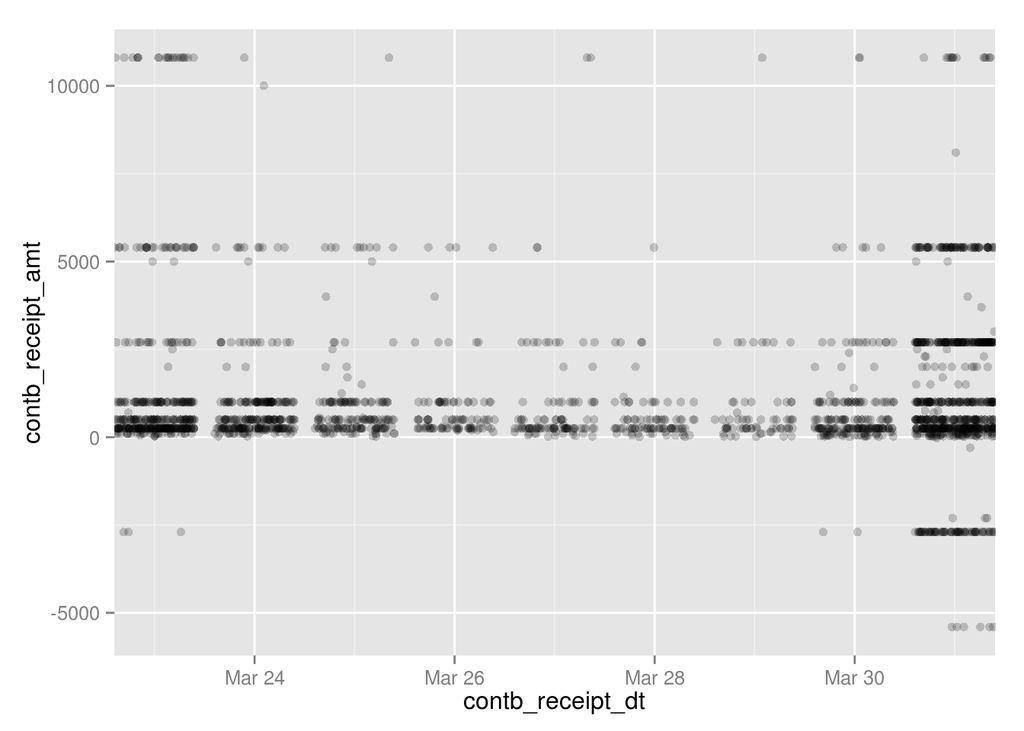

```r
ggplot(data = us, aes(x = contb_receipt_dt, y = contb_receipt_amt)) + geom_jitter(alpha = 1/5, h = 0, w = 1) + xlim(as.Date("2015-03-23"), max(us$contb_receipt_dt))
```

**Individuals’ Sum Contributions**

Next I decided I was interested in the individuals’ sum contributions to the campaign. I also created a new variable to indicate whether contributors are from Texas.

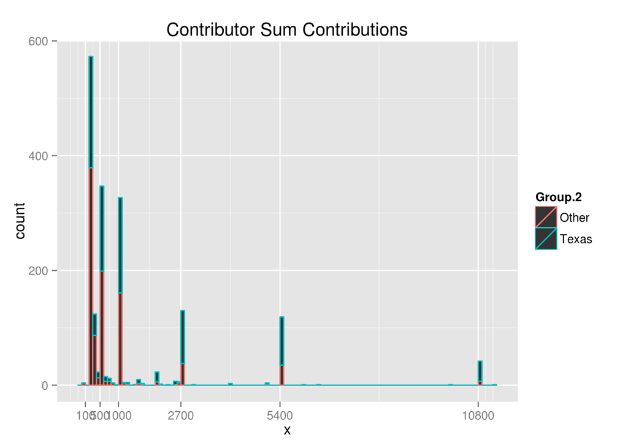

```r
#Create field for whether the contribution came from someone living in Texas
us$contbr_tx = ifelse(us$contbr_st == 'TX', 'Texas', 'Other')
us$contbr_tx = factor(us$contbr_tx)
#Aggregate by name and whether from Texas, save in new dataframe
us.sc = aggregate(x = us$contb_receipt_amt, by = list(us$contbr_nm, us$contbr_tx), FUN = sum)
#Plot new dataframe
qplot(data = us.sc, x = x, color = Group.2, main = 'Contributor Sum Contributions', binwidth = 100) + scale_x_continuous(breaks = c(100, 500, 1000, 2700, 5400, 10800))
```

[$5400 is the legal limit which individuals may contribute for the 2015-2016 election](http://www.insidepoliticallaw.com/2015/02/02/fec-increases-contribution-limits-permitting-individuals-to-contribute-over-800k-to-national-party-committees/). 111 individuals in this data set donated above the legal limit, five of which each had a total of $18900 in contributions attributed to them before accounting for refunds. With refunds added in, it looks like all contributors were returned to a maximum of $10800, which is the legal limit for a couple.

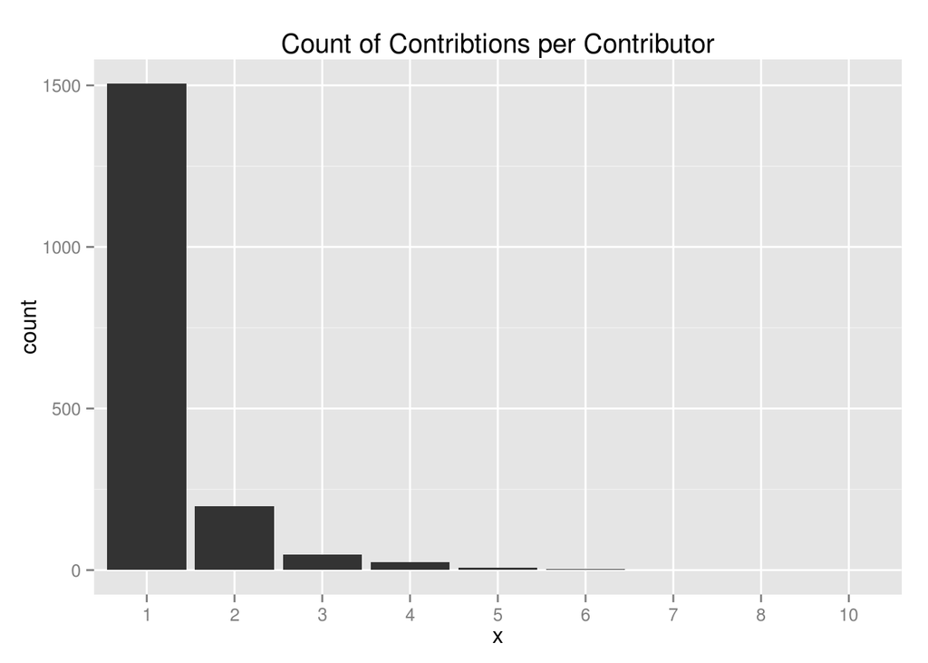

```r
#Create new dataframe without refunds included
us.cc = subset(us, us$contb_receipt_amt > 0)
#Aggregate by contributor name
us.cc = aggregate(x = us.cc$contb_receipt_amt, by = list(us.cc$contbr_nm), FUN = length)
us.cc$x = as.factor(us.cc$x)
#Plot
qplot(data = us.cc, x = x, main = 'Count of Contribtions per Contributor')
```

For the most part, the contributors gave only one time within this data set.

**Top Employer Sum Contributions**

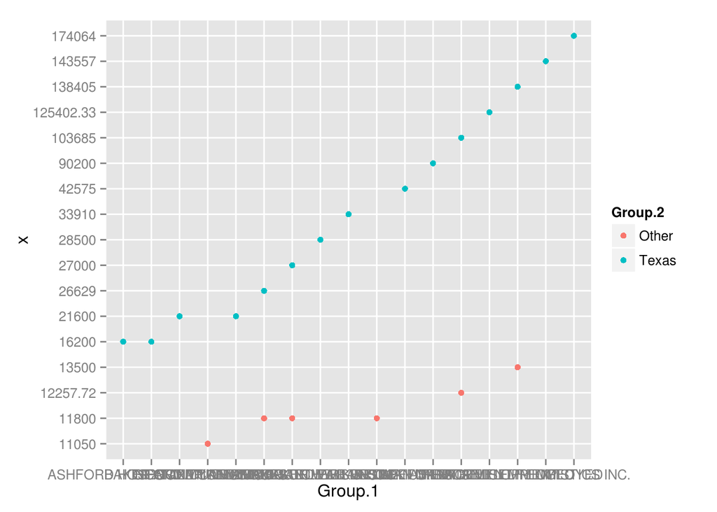

```r
#Aggregate by employer and whether from Texas, save to new data frame
us.ec = aggregate(x = us$contb_receipt_amt, by = list(us$contbr_employer, us$contbr_tx), FUN = sum)
#Only keep contributions which are creater than the legal limit for a couple
us.ec = subset(us.ec, us.ec$x > 10800)
us.ec$x = as.factor(us.ec[with(us.ec, order(x)), ]$x)
#Plot
qplot(data = us.ec, x = Group.1, y = x, color = Group.2)
```

```r
us.ec
```

```
##                                    Group.1 Group.2         x
## 112                        COOPER AND KIRK   Other     11050
## 207                              HOMEMAKER   Other     11800
## 219 INFORMATION REQUESTED PER BEST EFFORTS   Other     11800
## 300                                   NONE   Other     11800
## 354                                RETIRED   Other  12257.72
## 375                          SELF EMPLOYED   Other     13500
## 480                                          Texas     16200
## 504              ASHFORD HOSPITALITY TRUST   Texas     16200
## 516                     BAKER AND MCKENZIE   Texas     21600
## 635               GIBSON DUNN AND CRUTCHER   Texas     21600
## 665                              HOMEMAKER   Texas     26629
## 676 INFORMATION REQUESTED PER BEST EFFORTS   Texas     27000
## 685                     JACKSON WALKER LLP   Texas     28500
## 744             MORGAN LEWIS & BOCKIUS LLP   Texas     33910
## 772                    PLAINS ALL AMERICAN   Texas     42575
## 786                      REDMAN MANAGEMENT   Texas     90200
## 791                                RETIRED   Texas    103685
## 796                       RIDA DEVELOPMENT   Texas 125402.33
## 819                          SELF EMPLOYED   Texas    138405
## 820                          SELF-EMPLOYED   Texas    143557
## 858                       TELIGISTICS INC.   Texas    174064
```

For the most, the employer types which contributed more than $10,800 were classifications such as ‘self employed’ or ‘retired’. There was one actual company from outside of Texas, and nine from Texas.

**Cumulative Contributions by Occupation Over Time**

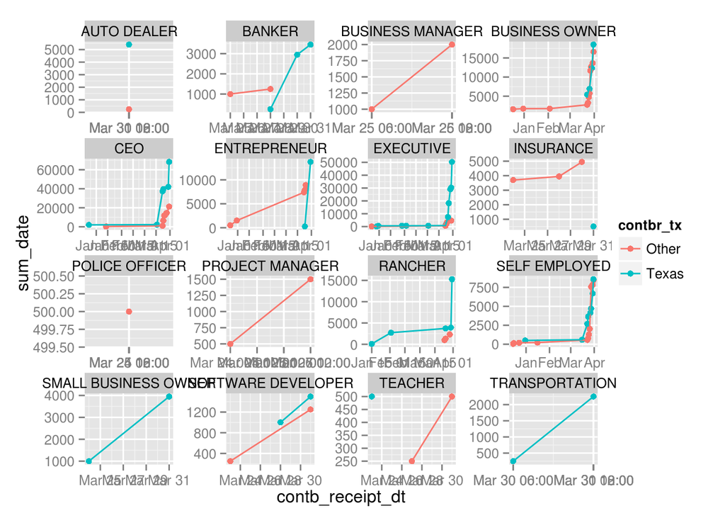

```r
#Ensure all subsets have at least two individuals
us.oc = aggregate(x = us$contbr_occupation, by = list(us$contbr_nm, us$contbr_occupation), FUN = length)
us.oc = aggregate(x = us.oc$Group.2, by = list(us.oc$Group.2), FUN = length)
us.oc = subset(us.oc, us.oc$x > 1)
us.oc$Group.1 = factor(us.oc$Group.1)
#Sample
set.seed(8902)
sample.ids = sample(levels(us.oc$Group.1), 16)
sample = subset(us, contbr_occupation %in% sample.ids)
#Sum contributions by group over time
sum_to_date = function(x) sample$sum_date = sum(subset(sample$contb_receipt_amt, sample$contb_receipt_dt <= x[12] & sample$contbr_tx == x[20] & sample$contbr_occupation == x[10]))
sample$sum_date = apply(sample, 1, sum_to_date)
#Plot
ggplot(data = sample, aes(x = contb_receipt_dt, y = sum_date, group = contbr_tx, color = contbr_tx)) + geom_point() + geom_line() + facet_wrap(~contbr_occupation, scales = 'free')
```

I thought it might be interesting to see how separate professions contributed together over time. There were 121 occupations listed with at least two individuals, so I sampled and plotted a few times.

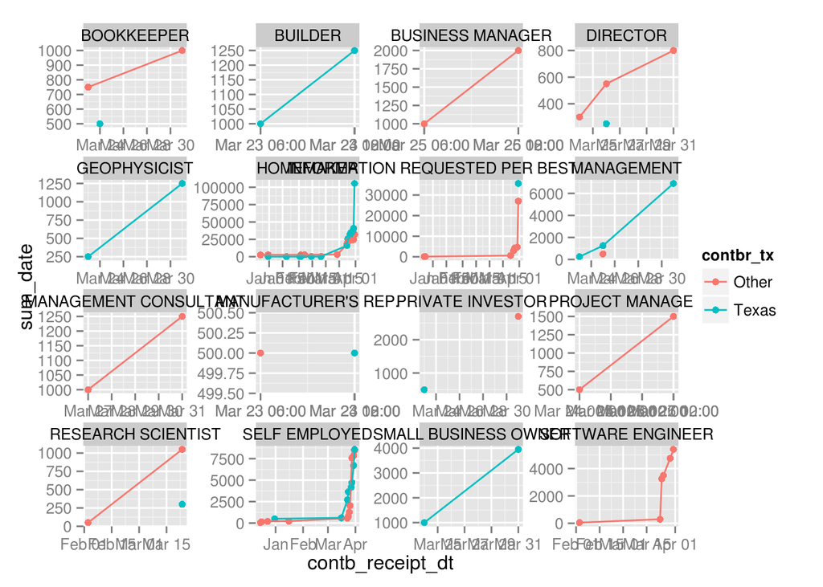

```r
#Sample, sum contributions by group over time, plot
set.seed(5892)
sample.ids = sample(levels(us.oc$Group.1), 16)
sample = subset(us, contbr_occupation %in% sample.ids)
sum_to_date = function(x) sample$sum_date = sum(subset(sample$contb_receipt_amt, sample$contb_receipt_dt <= x[12] & sample$contbr_tx == x[20] & sample$contbr_occupation == x[10]))
sample$sum_date = apply(sample, 1, sum_to_date)
ggplot(data = sample, aes(x = contb_receipt_dt, y = sum_date, group = contbr_tx, color = contbr_tx)) + geom_point() + geom_line() + facet_wrap(~contbr_occupation, scales = 'free')
```

**Engineer Cumulative Contributions Over Time**

Since that Ted Cruz is the chairman of the Subcommittee on Space, Science, and Competitiveness, I thought it might be interesting to consolidate all the individuals with ‘engineer’ in their occupation label and create a similar plot.

```r
#Create new dataframe including only contributions from contributors with 'engineer' in their occupation label
us.eg = us[grep('ENGINEER', us$contbr_occupation), ]
#Sum contributions by group over time
sum_to_date = function(x) us.eg$sum_date = sum(subset(us.eg$contb_receipt_amt, us.eg$contb_receipt_dt <= x[12] & us.eg$contbr_tx == x[20]))
us.eg$sum_date = apply(us.eg, 1, sum_to_date)
factor(unique(us.eg$contbr_occupation))
```

```
##  [1] ENGINEER                      CIVIL ENGINEER
##  [3] ELECTRICAL ENGINEER           SENIOR PRODUCT ENGINEER
##  [5] I/T SYSTEMS ENGINEER          DRILLING ENGINEER
##  [7] SOFTWARE ENGINEER             FIELD ENGINEER
##  [9] TOOL DESIGN ENGINEER          CONSULTING PETROLEUM ENGINEER
## [11] DATA NETWORK ENGINEER         CONTRACT SW ENGINEER
## [13] NUCLEAR ENGINEER              ENGINEER SALES / SERVICE
## [15] MECHANICAL ENGINEER           ENGINEERING
## [17] QA ENGINEER                   ELECTRICAL ENGINEERING
## [19] WIRELINE ENGINEER             PROJECT ENGINEER
## [21] STRUCTURAL ENGINEER
## 21 Levels: CIVIL ENGINEER ... WIRELINE ENGINEER
```

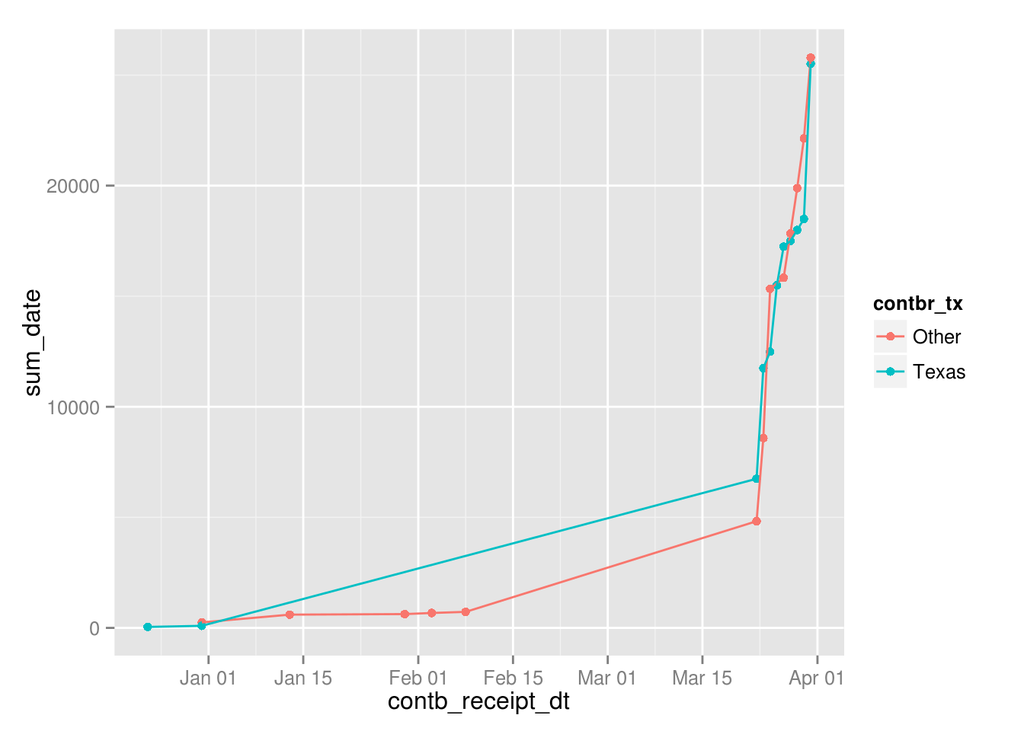

```r
#Plot
ggplot(data = us.eg, aes(x = contb_receipt_dt, y = sum_date, group = contbr_tx, color = contbr_tx)) + geom_point() + geom_line()
```

**All Cumulative Contributions Over Time**

Next I created a similar plot for all the data to compare the engineer plot with.

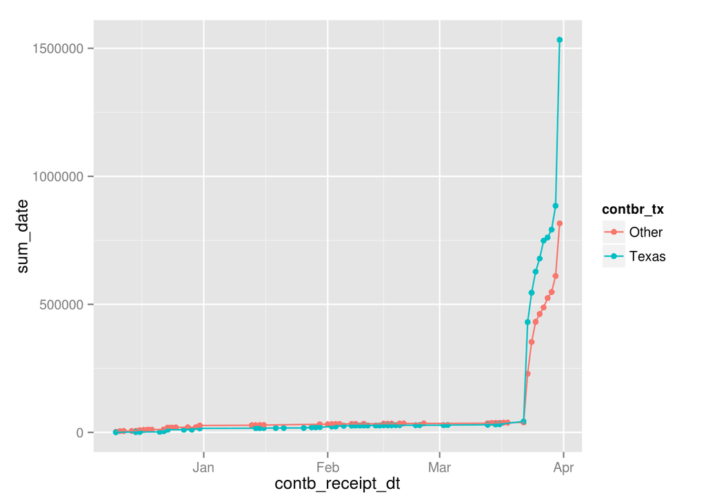

```r
#Sum contributions by group over time
sum_to_date = function(x) us$sum_date = sum(subset(us$contb_receipt_amt, us$contb_receipt_dt <= x[12] & us$contbr_tx == x[20]))
us$sum_date = apply(us, 1, sum_to_date)
#Plot
ggplot(data = us, aes(x = contb_receipt_dt, y = sum_date, group = contbr_tx, color = contbr_tx)) + geom_point() + geom_line()
```

**Sum Contribution by State**

Finally I compared the total contributions of each state in this data set.

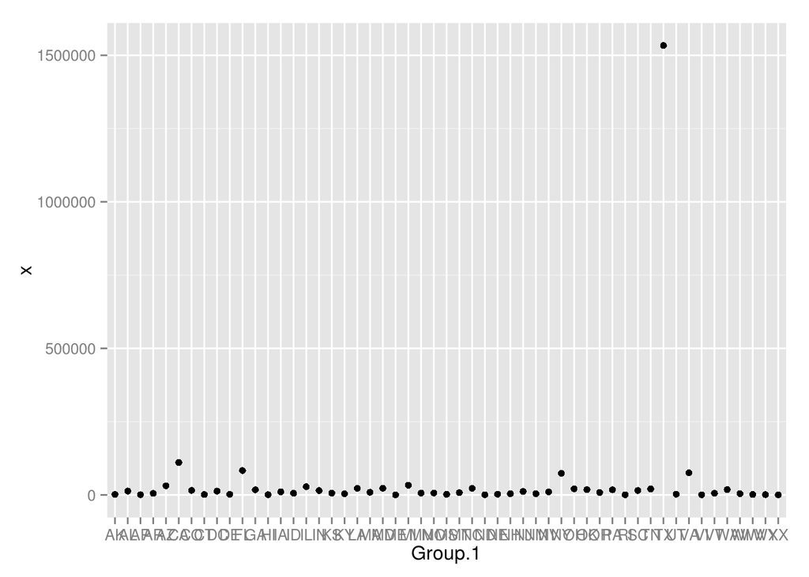

```r
#Create new data frame by aggregating by state
us.st = aggregate(x = us$contb_receipt_amt, by = list(us$contbr_st), FUN = sum)
#Plot
qplot(data = us.st, x = Group.1, y = x)
```

## Final Plots and Summary

### Contributions vs. Date, Week of Run Announcement

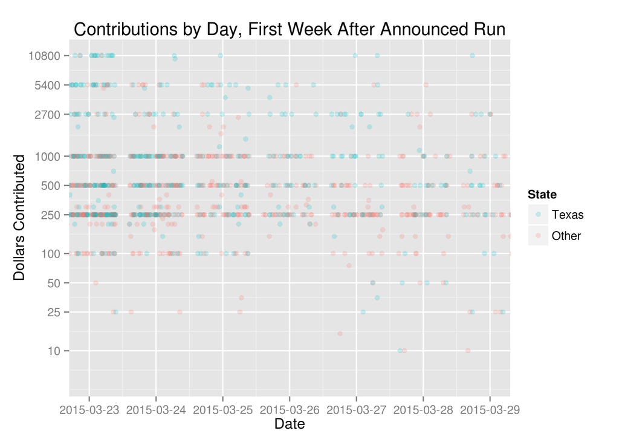

The immediate week following Ted Cruz’s announcement saw contributions ranging from $10 to $10,800. Contributions tended to be in the $1,000 to $250 range, with more contributions being made earlier in the week.

### Individuals’ Sum Contributions

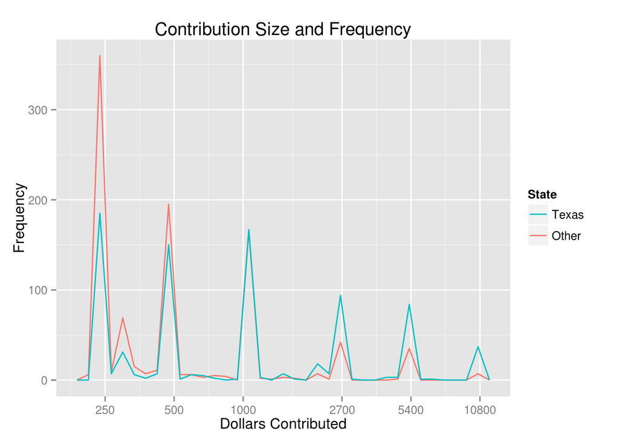

Looking at the entire data set, in general, more contributors from the combined other states gave small contributions, and more contributors from Texas gave large contributions. The tipping point was somewhere around $1000, at which point contribution frequency was about equal.

### Engineers and Cumulative Contributions over Time

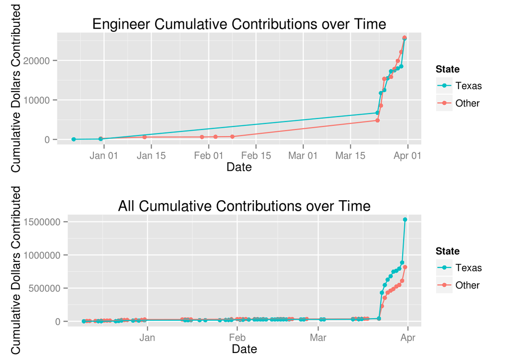

Engineers from Texas contributed almost equally to engineers from other states, overall. This trend is different from the trend of the greater data set - in overall terms Texans contributed considerably more cumulatively than the contributors from the combined other states.

Ted Cruz may hold greater than average appeal to engineers from outside Texas (compared with people of other occupations). An important piece of information not conveyed in these graphs is that there were almost twice as many engineers from other states (n = 43) than engineers from Texas (n = 24). This is pretty different from the much more level ratio of contributors from other states (n = 966) vs. contributors from Texas (n = 830) from the greater data set.

## Reflection

My biggest challenge in this data set was creating cumulative sums across the x axis when creating the occupation plots (at least this turned out to be much harder than I expected). Even now I still suspect that there’s some hidden pre-made function that does exactly what I wanted, but in this project it ended up being good practice in defining my own functions and using apply().

When I first began playing with this data set there was a moment where I suspected some sort of foul play - the patterns after March 23rd seemed far too regular at strange numbers. I’ve since learned about this season’s legal limits to individual contributions and Ted Cruz’s announcement date. I’m feeling a bit more confident that there’s no cheating going on in this data set, which feels like a victory.

This data set will get a lot more interesting as the campaign season approaches and there’s not just one candidate. In its current form, a much larger project that would be quite interesting would be to classify the different occupations listed into genres, then look into contributions across the genres. Incorporating whether individuals are from left or right leaning states would also be an interesting dimension.